# FM-PreRegistration

```r
library(tidyverse)
```

# IMPORT DATA

```r
sona_data = read.csv("../data/savic-rhyming-sona.csv") %>%
  select(-sona_id) %>% mutate(data_source = "sona")


prolific_data = read.csv ("../data/savic-rhyming-prolific.csv") %>%
  select(-PROLIFIC_PID) %>%
  mutate(data_source = "prolific")
```

Making sure sona data and prolific data have the same amount of columns for binding.

```r
ncol(sona_data)
```

```
## [1] 51
```

```r
ncol(prolific_data)
```

```
## [1] 52
```

Because there are uneven columns, we need to adjust the data begore we bind the data from Sona and prolific.

```r
prolific_data <- prolific_data %>% select(names(sona_data))

final_data = rbind(sona_data, prolific_data) %>%
 mutate(rt = as.numeric(rt),
        relatedness = as.factor(relatedness),
        condition = as.factor(condition))%>%
  mutate(condition = fct_recode(condition,
                                "non-rhyming" = "1",
                               "rhyming" = "2")) %>%
  mutate(relatedness = fct_recode(relatedness,
                                  "related" = "unrelated",
                                  "unrelated" = "related")) %>%
 mutate(correct = tolower(correct))
```

## Demographic Data: Basic Descriptives

```r
demographics = final_data %>%
  filter(typeoftrial == "demographics") %>%
  select("ID","gender", "age", "education", "race", "hispanic", "dominant_hand", "alert_time", "english")%>%
  mutate(across(c("age","education"), ~ replace_na(., NA)))%>%
 mutate(across(c("gender","race","hispanic","dominant_hand","alert_time","english"),
                 ~ replace_na(., "NOT_FOUND"))) %>%
mutate(across(c("age","gender","education","race","hispanic", "dominant_hand", "alert_time", "english"),
              ~ifelse(. == "", "blank",.)))

subject_age= demographics%>%
  summarise(mean_age= mean(age, na.rm = TRUE),
            sd_age=sd(age, na.rm = TRUE))

gender_distribution= demographics%>%
  filter(gender != "blank") %>%
  count(gender)

race_distribution= demographics%>%
  filter(race != "blank")%>%
  count(race)

education_distribution= demographics%>%
  filter(education != "blank")%>%
  count(education)

mean_education= demographics%>%
  summarise(mean_education= mean(education, na.rm = TRUE),
            sd_education=sd(education, na.rm = TRUE))
```

For demographics ( N = 213 ) Mean age (M = 33.91, SD = 15.41) Gender distribution: Women (N = 116) - 54.45% Men (N = 95) - 44.60% Nonbinary (N = 2) - 0.94% Race distribution: Asian (N = 11) - 5.16% Black/African American (N = 36) - 16.90% Other (N = 11) - 5.16% White/Caucasian (N = 142) - 66.67% Multiracial (N = 13) - 6.10% Mean education (M = 14.49, SD = 2.76).

## Verification of Recorded Data

```r
levels(final_data$condition)
```

```
## [1] "non-rhyming" "rhyming"
```

```r
levels(final_data$relatedness)
```

```
## [1] ""          "novel"     "unrelated" "related"
```

Our Condition and Relatedness columns indicate our independent variables. Condition has 2 levels: non-rhyming and rhyming Relatedness has 2 levels that we are evaluating (related and unrelated). In the data it has “novel” and “” too. No target trial has ““.

Our primary dependent variable columns are ‘reaction time’ and ‘correct’ for target trials. For our attention check and association task, we are looking at the response column.

## Participant Exclusions based on incomplete experiments.

```r
final_data%>%
group_by(ID)%>%
count()
```

| ID | n |
| --- | --- |
| 8298799 | 347 |
| 12054445 | 347 |
| 16777069 | 355 |
| 18075384 | 347 |
| 19865559 | 346 |
| 23547063 | 349 |
| 27746968 | 2 |
| 28359621 | 348 |
| 42712906 | 349 |
| 43108275 | 355 |

[output cut: 228 more lines]

There are 238 unique subjects. Subjects completed different numbers of ‘trials’ because of either slow responses to target trials or additional questions in demographics.

```r
final_data %>%
  filter(typeoftrial == "sentence") %>%
  group_by(ID) %>%
  count()
```

| ID | n |
| --- | --- |
| 8298799 | 60 |
| 12054445 | 60 |
| 16777069 | 60 |
| 18075384 | 60 |
| 19865559 | 60 |
| 23547063 | 60 |
| 28359621 | 60 |
| 42712906 | 60 |
| 43108275 | 60 |
| 45837842 | 60 |

[output cut: 216 more lines]

```r
final_data %>%
  filter(typeoftrial == "attention") %>%
  group_by(ID) %>%
  count()
```

| ID | n |
| --- | --- |
| 8298799 | 9 |
| 12054445 | 9 |
| 16777069 | 9 |
| 18075384 | 9 |
| 19865559 | 9 |
| 23547063 | 9 |
| 28359621 | 9 |
| 42712906 | 9 |
| 43108275 | 9 |
| 45837842 | 9 |

[output cut: 216 more lines]

226 participants started the Training phase. 214 finished given by 60 sentence trials and 9 attention check trials. 12 participants that did not not complete the Training phase.

```r
final_data %>%
  filter(typeoftrial == "target") %>%
  group_by(ID) %>%
  count()
```

| ID | n |
| --- | --- |
| 8298799 | 55 |
| 12054445 | 55 |
| 16777069 | 55 |
| 18075384 | 55 |
| 19865559 | 55 |
| 23547063 | 55 |
| 28359621 | 55 |
| 42712906 | 55 |
| 43108275 | 55 |
| 45837842 | 55 |

[output cut: 203 more lines]

213 participants completeted 55 trials (the full amount of target trials). 1 partcipant left the trial between the Test phase and Training phase. At this point, 25 participants have been excluded.

# Average accuracy in experiment and the standard deviation of the accuracy.

This histogram has been excluded from the results; however, we decided that this supplementary information will be kept in the code.

Average accuracy for target trials (not practice trials) before exclusions based on pre-registered threshold (M = 0.86, SD = 0.34)

```r
trial_data = final_data %>%
  filter(typeoftrial == "target") %>%
  select(type, correct, block_number, target, correct_key) %>%
  filter(block_number == 1) %>%
  mutate(correct = fct_recode(correct,
                              "0" = "false",
                              "1" = "true")) %>%
  mutate(correct = as.numeric(as.character(correct)))

trial_accuracy = trial_data %>%
   summarise(mean_accuracy = mean(correct, na.rm = TRUE),
    sd_accuracy = sd(correct, na.rm = TRUE))
```

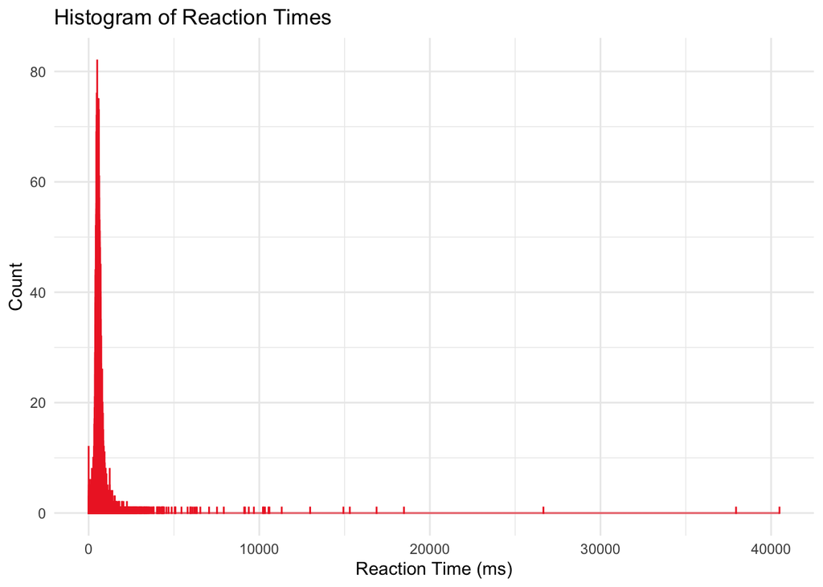

```r
basic_data = final_data %>%
  filter(typeoftrial == "target") %>%
  select(ID, rt, condition, relatedness, prime, response, type, correct, block_number, target, correct_key)

ggplot(basic_data, aes(x = rt)) +
  geom_histogram(binwidth = 2, color = "firebrick2") +
  theme_minimal() +
  labs(title = "Histogram of Reaction Times", x = "Reaction Time (ms)", y = "Count")
```

```r
geom_histogram(mapping = aes (x = as.numeric(rt)))
```

```
## mapping: x = ~as.numeric(rt)
## geom_bar: na.rm = FALSE, orientation = NA
## stat_bin: binwidth = NULL, bins = NULL, na.rm = FALSE, orientation = NA, pad = FALSE
## position_stack
```

## Other Pre-registeredExclusions

We excluded data from participants whose accuracy on attention check questions was less than 0.75. On the priming task, incorrect identification of the familiar noun or reaction times that are extremely short (less than 200 ms) or extremely long (greater than 1,500 ms) will result in removal of data. In addition, incomplete experiments will be removed from analyses. Finally, English fluency is necessary, so data will be removed if a participant’s first language is not English or they did not learn before the age of 4.

The data collected for the attention check questions was adjusted to account for typos of 1-2 letters.

```r
#editing all attention trials to adjust for typos

attention_trials= final_data%>%
  filter(typeoftrial == "attention") %>%
  select(ID, response, novel1, novel2, correct) %>%
    rowwise() %>%
  mutate(response = ifelse(is.na(response), "blank", response)) %>%
  mutate(across(c(novel1, novel2), ~ replace_na(., "NOT_FOUND"))) %>%
  mutate(edit_novel1 = adist(novel1, response),
         edit_novel2 = adist(novel2, response)) %>%
  mutate(revised_correct = ifelse(edit_novel1 <= 2 |
                                    edit_novel2 <= 2,
                                    1, 0),
          mismatch = ifelse(correct == revised_correct, 0, 1)) %>%
  ungroup()

# mean accuracy for each participant
subject_attention_accuracy = attention_trials  %>%
  group_by(ID)  %>%
  summarise(mean_accuracy = mean(revised_correct))
print(subject_attention_accuracy)
```

```
## # A tibble: 226 × 2
##          ID mean_accuracy
##       <int>         <dbl>
##  1  8298799         1
##  2 12054445         1
##  3 16777069         1
##  4 18075384         1
##  5 19865559         1
##  6 23547063         1
##  7 28359621         0.667
##  8 42712906         0.667
##  9 43108275         0.778
## 10 45837842         1
## # ℹ 216 more rows
```

```r
# find IDs with less than 75% accuracy
low_acc_IDs = subject_attention_accuracy  %>%
  filter(mean_accuracy < 0.75)  %>%
  pull(ID)
```

### Target data after applying exclusions

```r
priming_data = final_data %>%
  filter(typeoftrial == "target") %>%
  select (ID, rt, condition, relatedness, prime, response, type, correct, block_number, target, correct_key) %>%
  filter(!is.na(rt), rt> 200 , rt< 1500, correct == "true", block_number == 1) %>%
  filter(relatedness %in% c("related", "unrelated")) %>%
  filter(!ID %in% low_acc_IDs)

# average reaction time for each subject in each condition in experiment
subject_reaction_time = priming_data %>%
  group_by(ID, condition) %>%
  summarise(mean_rt = mean(rt, na.rm = TRUE),
            sd_rt = sd(rt, na.rm = TRUE))
```

[output not shown]

```r
priming_accuracy = priming_data %>%
  mutate(acc = ifelse(correct == "true", 1,0)) %>%
  group_by(ID) %>%
  summarize(acc = mean(acc))

counts = final_data %>%
  group_by(condition, relatedness)%>%
  count()
```

```r
priming_data%>%
  group_by(condition, ID)%>%
  count()%>%
  group_by(condition)%>%
  count()
```

| condition | n |
| --- | --- |
| non-rhyming | 74 |
| rhyming | 73 |

## Bar plot: Mean Reaction Time by Condition and Relatedness

```r
mean_scores = priming_data %>%
  group_by(condition, relatedness) %>%
  summarise(mean_rt = mean(rt, na.rm = TRUE),
          sd_rt = sd(rt, na.rm = TRUE)) %>%
  left_join(counts)%>%
  mutate(SE = sd_rt/sqrt(n),
         ymin = mean_rt - 1.96*SE,
          ymax = mean_rt + 1.96*SE)
```

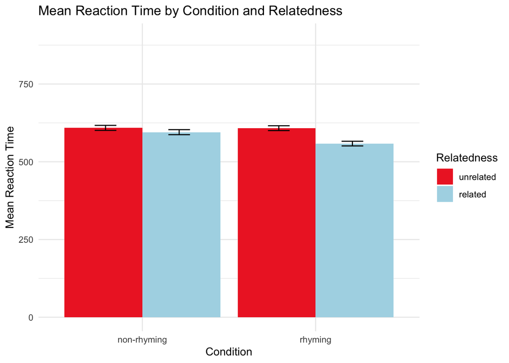

```r
mean_scores %>%
  ggplot(mapping = aes(x = condition, y = mean_rt, group = relatedness, fill = relatedness)) +
  geom_col(position = "dodge") +
  geom_errorbar(
    aes(ymin = ymin, ymax = ymax),
    width = 0.25,
    position = position_dodge(width = .85)) +
  theme_minimal() +
  ylim(0, 900)+
  scale_fill_manual(values = c("firebrick2", "lightblue")) +
  labs(
    title = "Mean Reaction Time by Condition and Relatedness",
    x = "Condition",
    y = "Mean Reaction Time"
  ) +
  guides(fill = guide_legend(title = "Relatedness"))
```

## INFERENTIAL STATISTICS

Priming model (rt_model)

```r
#install.packages("lmerTest")
library(lmerTest)
library(performance)

rt_model = lmer(data = priming_data, rt~ relatedness*condition + (1|ID))
```

```r
car::Anova(rt_model)
```

|  | Chisq | Df | Pr(>Chisq) |
| --- | --- | --- | --- |
| relatedness | 44.828724 | 1 | 2.150448e-11 |
| condition | 2.179177 | 1 | 1.398892e-01 |
| relatedness:condition | 17.244691 | 1 | 3.286145e-05 |

```r
nobs(rt_model)
```

```
## [1] 4062
```

```r
print(nobs(rt_model))
```

```
## [1] 4062
```

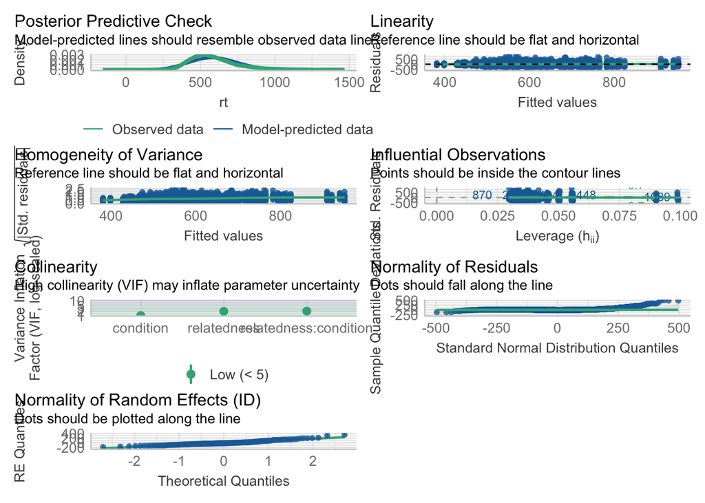

```r
check_model(rt_model)
```

```r
emmeans :: emmeans(rt_model,
                   pairwise ~ relatedness | condition,
                   adjust = "tukey")
```

[output not shown]

[output not shown]

```
## $emmeans
## condition = non-rhyming:
##  relatedness emmean   SE  df asymp.LCL asymp.UCL
##  unrelated      611 11.7 Inf       588       634
##  related        600 11.7 Inf       577       623
##
## condition = rhyming:
##  relatedness emmean   SE  df asymp.LCL asymp.UCL
##  unrelated      606 11.8 Inf       583       629
##  related        559 11.7 Inf       536       581
##
## Degrees-of-freedom method: asymptotic
## Confidence level used: 0.95
##
## $contrasts
## condition = non-rhyming:
##  contrast            estimate   SE  df z.ratio p.value
##  unrelated - related     11.0 6.14 Inf   1.799  0.0720
##
## condition = rhyming:
##  contrast            estimate   SE  df z.ratio p.value
##  unrelated - related     47.1 6.14 Inf   7.671  <.0001
##
## Degrees-of-freedom method: asymptotic
```

Our primary research question is whether exposure to language containing rhyming words can help to foster semantic links between novel and familiar words. If rhyming facilitates semantic integration, participants should identify familiar nouns faster when the prime is related to and rhymes with the familiar noun.